# Some model output analysis rendered using RMarkdown

Marcus Low

March 2022

# Analysis

## The numbers

The below is based on 10000 runs of each of the five scenarios.

Comparing key numbers from the five simulations:

|  | Scenario | standard | cti | x_ray | tut | ultra | ctiDstd | xrayDstd | tutDstd | ultraDstd |
| --- | --- | --- | --- | --- | --- | --- | --- | --- | --- | --- |
| 1 | latentTB | 7297.202 | 7051.205 | 6894.212 | 6410.751 | 6271.045 | 0.96628885975748 | 0.944774723243238 | 0.878521795066109 | 0.859376648748383 |
| 2 | activeTB | 789.408 | 759.723 | 742.164 | 686.324 | 671.725 | 0.962395871336495 | 0.940152620698042 | 0.869416068750253 | 0.850922463415623 |
| 3 | Deaths | 182.113 | 172.55 | 158.553 | 133.548 | 124.081 | 0.947488647158632 | 0.870629773821748 | 0.733324913652513 | 0.681340706045148 |
| 4 | Peak_time | 418.944 | 422.636 | 423.49 | 427.44 | 423.235 | 1.00881263366942 | 1.01085109227009 | 1.02027956003666 | 1.01024241903452 |
| 5 | cases100k | 394.704 | 379.8615 | 371.082 | 343.162 | 335.8625 | 0.962395871336495 | 0.940152620698042 | 0.869416068750253 | 0.850922463415623 |
| 6 | detected100k | 227.4855 | 222.704 | 230.639 | 240.6595 | 246.176 | 0.978981077914856 | 1.01386242200052 | 1.0579113833629 | 1.08216128060909 |
| 7 | case_detection_rate | 0.57636194195746 | 0.586328576649861 | 0.621583223085534 | 0.701464385497308 | 0.733167739104402 | 1.01729231923009 | 1.07845986668463 | 1.21705535087027 | 1.27206133113924 |
| 8 | R0 | 1.02653735 | 1.02592291 | 1.02545139 | 1.02370202 | 1.02293578 | 0.999401444087738 | 0.998942113504199 | 0.997237967035491 | 0.996491535354267 |
| 9 | total_time_infectious | 40616.842 | 38933.708 | 37316.443 | 32971.8 | 31750.208 | 0.958560687706839 | 0.918743091843526 | 0.811776553184514 | 0.781700556631163 |
| 10 | total_time_active | 18741.098 | 18096.504 | 17454.523 | 15409.764 | 14783.138 | 0.965605323658198 | 0.931350073512235 | 0.822244459742967 | 0.788808531922729 |
| 11 | mean_time_infectious | 48.1466997 | 47.9057638 | 46.9881493 | 44.8314979 | 44.1053046 | 0.994995796150073 | 0.975937075495956 | 0.931143737355688 | 0.916060807382816 |
| 12 | mean_time_active | 23.7657438 | 23.8486371 | 23.5590032 | 22.5663425 | 22.128008 | 1.00348793207137 | 0.991300899238003 | 0.949532347479064 | 0.931088384450227 |

Here are the mean and IQR calculations to be used in the article. The mean here is the mean of all years in all runs of the model’s base scenario - same with the IQR. The sequence is is min, 25th, mean, 75th, max.

Mean cases per 100k: 150, 358.875, 396, 433.5, 559.5

Mean detected per 100k: 85, 206, 228.5, 250.5, 330

Mean case detection rate: 0.5276705, 0.5648662, 0.5765484, 0.5882528, 0.6243478

And below is a table with mean case detection over time in the five scenarios

|  | year | Scenario1 | Scenario2 | Scenario3 | Scenario4 | Scenario5 |
| --- | --- | --- | --- | --- | --- | --- |
| 1 | 1 | 0.477 | 0.481 | 0.502 | 0.615 | 0.613 |
| 2 | 2 | 0.568 | 0.574 | 0.602 | 0.683 | 0.709 |
| 3 | 3 | 0.573 | 0.581 | 0.614 | 0.694 | 0.735 |
| 4 | 4 | 0.57 | 0.579 | 0.619 | 0.691 | 0.73 |
| 5 | 5 | 0.57 | 0.577 | 0.62 | 0.696 | 0.729 |
| 6 | 6 | 0.571 | 0.587 | 0.627 | 0.697 | 0.736 |
| 7 | 7 | 0.578 | 0.587 | 0.623 | 0.708 | 0.735 |
| 8 | 8 | 0.582 | 0.592 | 0.627 | 0.706 | 0.74 |
| 9 | 9 | 0.584 | 0.595 | 0.63 | 0.709 | 0.74 |
| 10 | 10 | 0.587 | 0.598 | 0.627 | 0.715 | 0.741 |

And here is the same information on a graph.

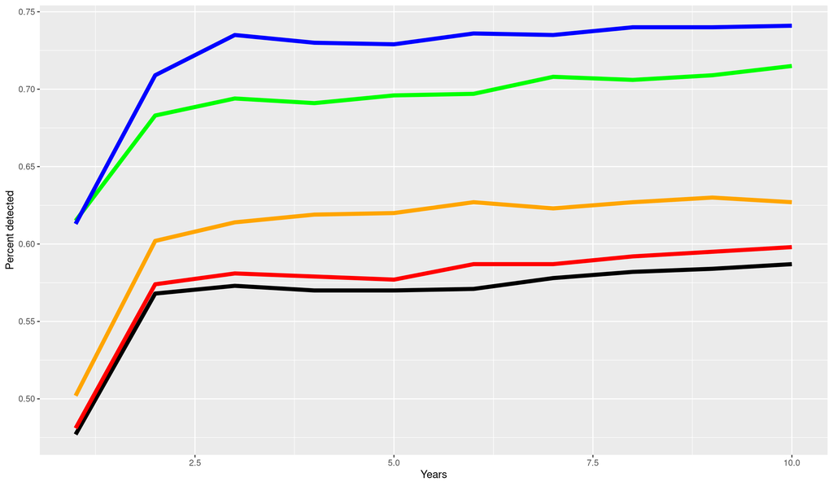

## Some epidemiological curves

This graph shows mean active TB cases per 100,000 by year. Different colours indicate the different scenarios.

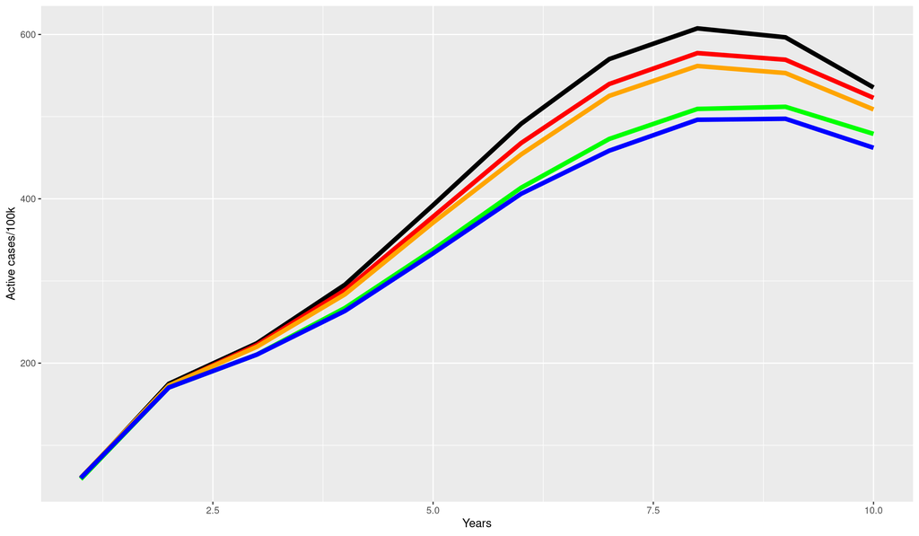

This table shows mean cases per 100,000 per year..

|  | year | Scenario1 | Scenario2 | Scenario3 | Scenario4 | Scenario5 |
| --- | --- | --- | --- | --- | --- | --- |
| 1 | 1 | 59.315 | 59.99 | 60.595 | 58.83 | 60.22 |
| 2 | 2 | 174.885 | 172.515 | 172.77 | 170.34 | 170.355 |
| 3 | 3 | 224.245 | 222.04 | 219.95 | 210.455 | 210.415 |
| 4 | 4 | 295.51 | 288.775 | 283.77 | 267.205 | 263.56 |
| 5 | 5 | 392.27 | 378.26 | 371.01 | 338.115 | 333.66 |
| 6 | 6 | 491.355 | 467.915 | 454.015 | 413.515 | 406.125 |
| 7 | 7 | 570.05 | 539.725 | 525.29 | 472.86 | 458.575 |
| 8 | 8 | 607.42 | 577.315 | 561.63 | 509.37 | 496.205 |
| 9 | 9 | 596.515 | 569.26 | 553.025 | 511.955 | 497.42 |
| 10 | 10 | 535.475 | 522.82 | 508.765 | 478.975 | 462.09 |

Below is a similar graph to the above, but showing only the detected TB cases per 100k instead of actual cases.

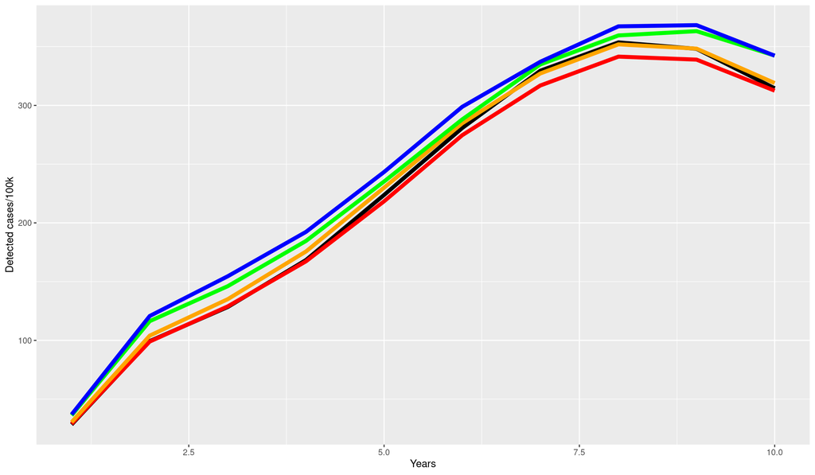

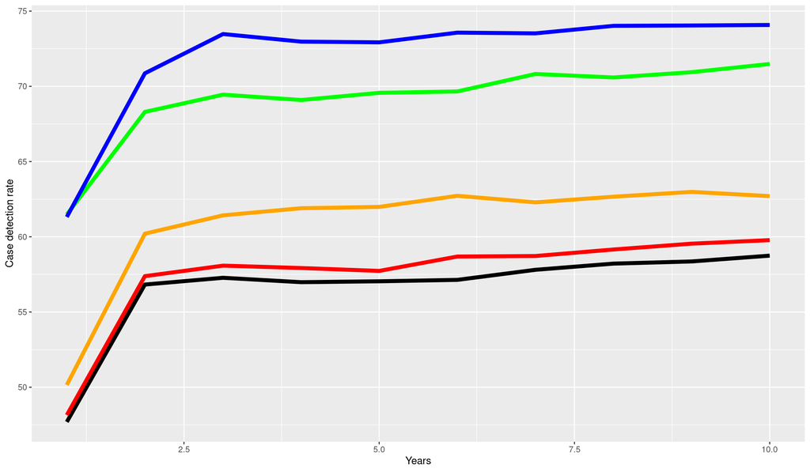

|  | Year | Scenario1 | Scenario2 | Scenario3 | Scenario4 | Scenario5 |
| --- | --- | --- | --- | --- | --- | --- |
| 1 | 1 | 47.6945123493214 | 48.1496916152692 | 50.1526528591468 | 61.4822369539351 | 61.3168382597144 |
| 2 | 2 | 56.8259141721703 | 57.3834159348462 | 60.2072119002142 | 68.3016320300575 | 70.8667194975199 |
| 3 | 3 | 57.2744096858347 | 58.0818771392542 | 61.4253239372585 | 69.4471502221378 | 73.4762255542618 |
| 4 | 4 | 56.9828432201956 | 57.9239892649987 | 61.89872079501 | 69.0911472464961 | 72.9719987858552 |
| 5 | 5 | 57.0423432839626 | 57.7314545550679 | 61.9875475054581 | 69.5680463747542 | 72.9245339567224 |
| 6 | 6 | 57.1358793540312 | 58.6880095743885 | 62.7236985562151 | 69.6601090649674 | 73.5697137580794 |
| 7 | 7 | 57.8063327778265 | 58.7224975682061 | 62.2884501894192 | 70.8201158905384 | 73.5212342583002 |
| 8 | 8 | 58.2175430509367 | 59.1557468626313 | 62.6649217456332 | 70.5891591573905 | 74.0218256567346 |
| 9 | 9 | 58.3614829467826 | 59.5430910304606 | 62.9844943718639 | 70.941781992558 | 74.0450725744843 |
| 10 | 10 | 58.7469069517718 | 59.7777437741479 | 62.7028195728873 | 71.4870295944465 | 74.0786426886537 |

## Where agents get infected

The below numbers are only for the base scenario, since it is the scenario used for calibration. Based on a TB study that we are using to calibrate the model, we want the following spread of TB infections by space:

Home 15.6, work 41.4, school 10.2, block 10.9, taxi 21.9

|  | Home | Work | School | Block | Taxi |
| --- | --- | --- | --- | --- | --- |
| 1 | 14.6 | 43.3 | 7.9 | 10.2 | 24 |

And here it is with quantiles.

Home 12.5, 14.2, 14.6, 15, 16.2

Work 38.7, 42.5, 43.4, 44.2, 47.1

School 3.8, 7, 7.9, 8.7, 13.9

Block 8.7, 9.9, 10.1, 10.4, 11.4

Taxi 21, 23.3, 24, 24.7, 27.9

## Histograms

Infections - for all five scenarios combined

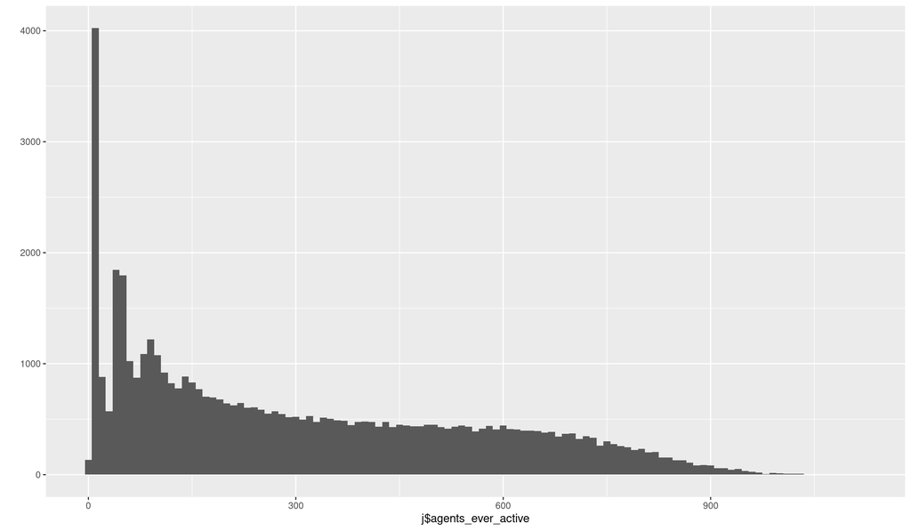

Infections - Scenario 1 - standard

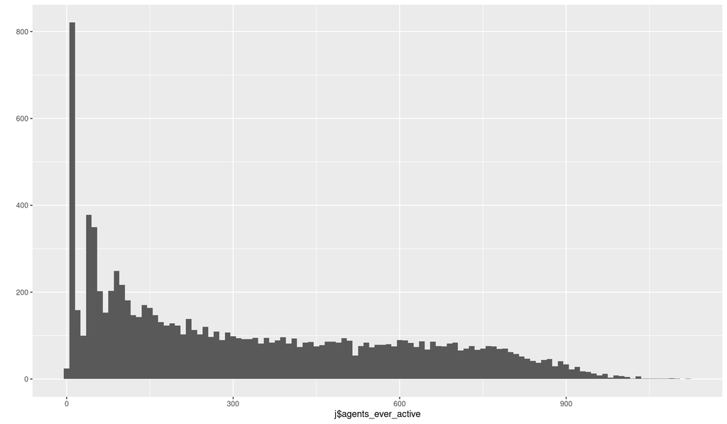

Infections - Scenario 2 - standard + cti

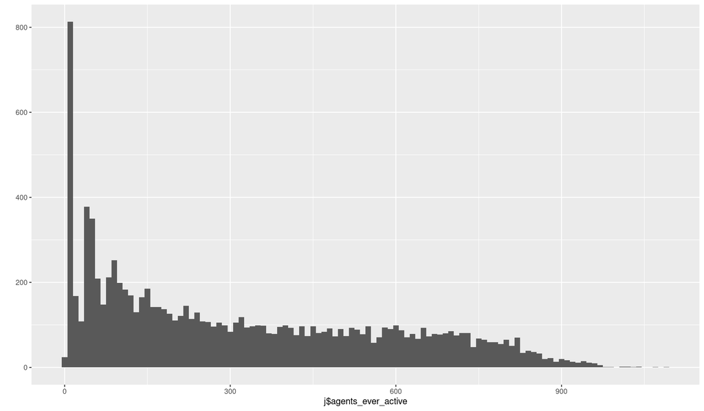

Infections - Scenario 3 - standard + mass X-ray screening

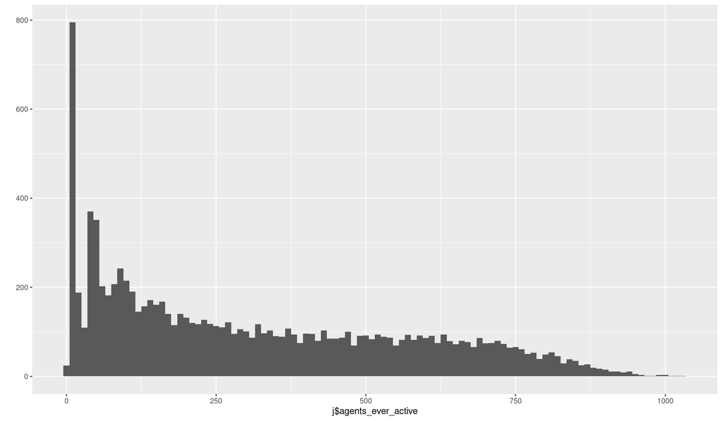

Infections - Scenario 4 - standard + TUT

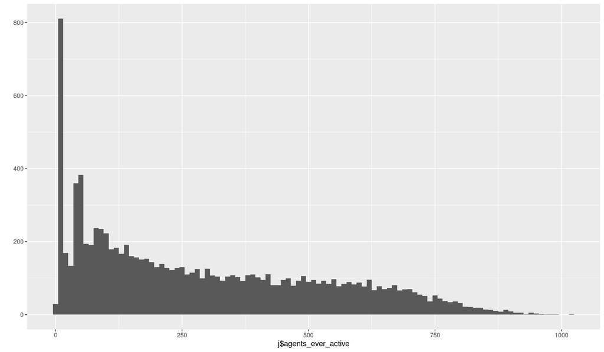

Infections - Scenario 5 - ultra (standard + TUT + mass x_ray)

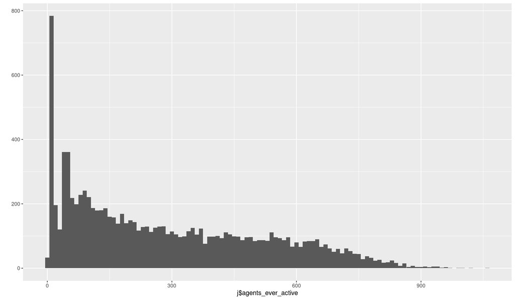

## Flowchart

This flowchart shows the possible disease progression paths.

[interactive chart not shown]